# 4 Predictions from Logistic Regression Models

# 5 Predictions from logistic regression models

The fitted model gives a linear predictor on the log-odds scale:

$$\hat{\eta}_i =
b_0 +
b_1 \text{studytime}_i +
b_2 \text{failures}_i +
b_3 \text{absences}_i.$$

For most audiences, the useful output is not the log-odds. It is the predicted probability:

$$\hat{p}_i = \frac{1}{1 + e^{-\hat{\eta}_i}}.$$

## 5.1 Predicting on different scales

By default, `predict()` returns values on the link scale:

**Output**

```
       1        2        3        4
1.054033 1.093833 1.133634 1.173434
```

**Code**

```r
new_students <- data.frame(
  studytime = c(1, 2, 3, 4),
  failures = 0,
  absences = 4
)

predict(fit_multi, newdata = new_students)
```

For logistic regression, the link scale is the log-odds scale. To get predicted probabilities, use `type = "response"`:

**Output**

```
        1         2         3         4
0.7415486 0.7491029 0.7565089 0.7637652
```

**Code**

```r
predict(fit_multi, newdata = new_students, type = "response")
```

**Key-point**

Use `type = "response"` when you want predicted probabilities from a logistic regression model.

- Continue

## 5.2 Scenario-based predictions

Predicted probabilities are often the clearest way to communicate a logistic regression model. We choose realistic predictor values and compare the model’s predictions.

**Output**

```
  studytime failures absences predicted_probability
1         1        0        4             0.7415486
2         2        0        4             0.7491029
3         4        0        4             0.7637652
```

**Code**

```r
scenarios <- data.frame(
  studytime = c(1, 2, 4),
  failures = c(0, 0, 0),
  absences = c(4, 4, 4)
)

scenarios$predicted_probability <- predict(
  fit_multi,
  newdata = scenarios,
  type = "response"
)

scenarios
```

These are model-based probabilities, not guarantees. A student with a high predicted probability can still fail, and a student with a low predicted probability can still pass.

**Exercise 4.1:** Predict a probability**

Compute the predicted probability for a student with `studytime = 3`, `failures = 0`, and `absences = 2`. Store it as `p_case`.

- Continue

## 5.3 From probabilities to classifications

Sometimes we need to turn probabilities into predicted classes. To do this, we choose a **classification threshold**. With a threshold of 0.5, we predict a pass when $\hat{p} \ge 0.5$.

**Output**

```
         Actual
Predicted   0   1
        0  36  18
        1  94 247
```

**Code**

```r
threshold <- 0.5
class_hat <- ifelse(prob >= threshold, 1, 0)
conf_mat <- table(
  Predicted = factor(class_hat, levels = c(0, 1)),
  Actual = factor(students$pass_exam, levels = c(0, 1))
)
conf_mat
```

From the confusion matrix we can calculate performance measures:

**Output**

```
   accuracy sensitivity specificity
  0.7164557   0.9320755   0.2769231
```

**Code**

```r
true_pos <- conf_mat["1", "1"]
true_neg <- conf_mat["0", "0"]
false_pos <- conf_mat["1", "0"]
false_neg <- conf_mat["0", "1"]

accuracy <- (true_pos + true_neg) / sum(conf_mat)
sensitivity <- true_pos / (true_pos + false_neg)
specificity <- true_neg / (true_neg + false_pos)

c(accuracy = accuracy,
  sensitivity = sensitivity,
  specificity = specificity)
```

**Key-point**

The threshold is a decision rule, not part of the fitted logistic regression model. Changing the threshold changes the classifications but not the predicted probabilities.

## 5.4 Threshold trade-offs

Lower thresholds predict more passes. Higher thresholds predict fewer passes. The right threshold depends on the cost of different mistakes.

**Output**

```
  threshold  accuracy sensitivity specificity
1       0.3 0.7037975   0.9773585   0.1461538
2       0.5 0.7164557   0.9320755   0.2769231
3       0.7 0.7265823   0.8566038   0.4615385
```

**Code**

```r
thresholds <- c(0.3, 0.5, 0.7)

threshold_summary <- do.call(rbind, lapply(thresholds, function(t) {
  pred <- ifelse(prob >= t, 1, 0)
  cm <- table(
    Predicted = factor(pred, levels = c(0, 1)),
    Actual = factor(students$pass_exam, levels = c(0, 1))
  )
  tp <- cm["1", "1"]
  tn <- cm["0", "0"]
  fp <- cm["1", "0"]
  fn <- cm["0", "1"]
  data.frame(
    threshold = t,
    accuracy = (tp + tn) / sum(cm),
    sensitivity = tp / (tp + fn),
    specificity = tn / (tn + fp)
  )
}))

threshold_summary
```

**Exercise 4.2:** Accuracy at a different threshold**

Using a threshold of 0.6, compute the classification accuracy and store it as `accuracy_06`.

## 5.5 ROC curves and AUC

An ROC curve shows the trade-off between sensitivity and false positive rate across many thresholds. AUC summarises that curve.

**Plot**

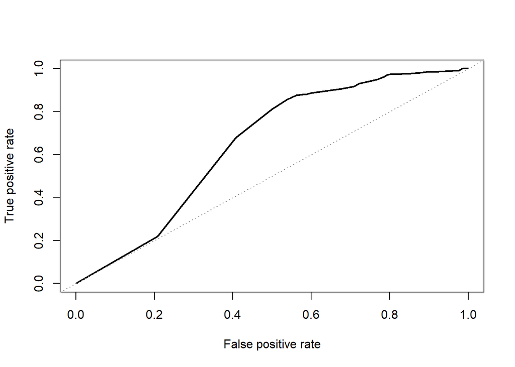

```
[1] 0.6483745
```

**Code**

```r
roc_thresholds <- seq(1, 0, by = -0.02)
actual <- students$pass_exam

tpr <- sapply(roc_thresholds, function(t) {
  pred <- ifelse(prob >= t, 1, 0)
  tp <- sum(pred == 1 & actual == 1)
  fn <- sum(pred == 0 & actual == 1)
  tp / (tp + fn)
})

fpr <- sapply(roc_thresholds, function(t) {
  pred <- ifelse(prob >= t, 1, 0)
  fp <- sum(pred == 1 & actual == 0)
  tn <- sum(pred == 0 & actual == 0)
  fp / (fp + tn)
})

roc_df <- data.frame(fpr = fpr, tpr = tpr)
roc_df <- roc_df[order(roc_df$fpr), ]

plot(roc_df$fpr, roc_df$tpr, type = "l", lwd = 2,
     xlab = "False positive rate",
     ylab = "True positive rate")
abline(0, 1, lty = 3, col = "grey60")

auc <- sum(diff(roc_df$fpr) *
             (head(roc_df$tpr, -1) + tail(roc_df$tpr, -1)) / 2)
auc
```

**Key-point**

AUC near 0.5 indicates little discrimination. Values closer to 1 indicate stronger discrimination between students who passed and students who failed.

## 5.6 Chapter summary

Prediction from logistic regression has two stages. First, use the fitted model to produce predicted probabilities. Second, if a classification is needed, choose a threshold that reflects the decision context. Probability predictions and classification decisions should be reported separately.